# Pixel-level nitrogen removal factors

last run by: jvillasenor

June 23, 2020

Sanitation factors were calculated at the country level (for rural and urban) by Gordon here. Here, we’ll take those values and assign them to 1km pixels to obtain a gridded version of country-level sanitation factors dat account for urban / rural characteristics as well as river presence.

Each country has four values of sanitation factors. These represent the factorial combinations between urban/rural and river/no river. We do this because centers away from rivers (more than 1 km) are unlikely to deposit N into the watershed.

```r
n_factors <- read.csv(nitrogen_factors_imputed_fn,
                     stringsAsFactors = F) %>%
  select(ISO3, contains("_n"), -contains("national"))

n_factors
```

```
##     ISO3   urban_n   rural_n urban_n_river rural_n_river urban_n_open
## 1    ABW 0.3399774 0.6404875   0.083700000   0.024809601   0.14105760
## 2    AFG 0.7256624 0.9845024   0.036572625   0.004500000   0.62938662
## 3    AGO 0.3918605 0.8310704   0.085777758   0.006195863   0.18025771
## 4    AIA 0.3399774 0.6404875   0.083700000   0.024809601   0.14105760
## 5    ALA 0.4728209 0.5647069   0.435223850   0.336208815   0.03479275
## 6    ALB 0.4775000 0.4678780   0.445500000   0.429869267   0.03000000
## 7    AND 0.4777464 0.3583438   0.422914568   0.162432256   0.03000000
## 8    ARE 0.3905979 0.3614525   0.320724745   0.041207606   0.04795487
## 9    ARG 0.4334071 0.4201523   0.310624217   0.028843106   0.08939095
## 10   ARM 0.4792644 0.8643318   0.437350879   0.088238763   0.03991348
## 11   ASM 0.2881000 0.3897000   0.004500000   0.004500000   0.10200000
## 12   ATA        NA        NA            NA            NA           NA
## 13   ATF 0.8443762 0.9943609   0.031183800   0.004500000   0.79072625
## 14   ATG 0.3399774 0.6404875   0.083700000   0.024809601   0.14105760
```

[output cut: 759 more lines]

```r
world_vector_n <- st_read(world_vector_fn) %>%
  left_join(n_factors, by = c("ISO3" = "ISO3"))
```

```r
rural_urban_input <- raster(rural_urban_input_fn)
# Codes: -200 = NaN, 10 = Water, 111 = Rural, 222 = Urban
rec <- c(-201, 11, NA, 11, 112, 0, 113, 223, 1)
recmat <- matrix(rec, ncol = 3, byrow = T)

rural_urban_input <- reclassify(x = rural_urban_input,
                                rcl = recmat)
```

```r
river <- raster(riv_15s_coastlines_fn) #load river raster
```

## Rasterize

Now that the fudge factors are attributed to polygons, we’ll rasterize them.

```r
# Main rasters
## General
n_raster_urban <- fasterize(sf = world_vector_n,
                            raster = rural_urban_input,
                            field = "urban_n")

n_raster_rural <- fasterize(sf = world_vector_n,
                            raster = rural_urban_input,
                            field = "rural_n")
```

```r
n_raster_rural_urban <- n_raster_urban
n_raster_rural_urban[rural_urban_input == 0] <- n_raster_rural[rural_urban_input == 0]

# Remove rasters to save space
rm(n_raster_urban)
rm(n_raster_rural)
```

```r
## Further away than 1 km from rivers
n_raster_urban_river <- fasterize(sf = world_vector_n,
                            raster = rural_urban_input,
                            field = "urban_n_river")

n_raster_rural_river <- fasterize(sf = world_vector_n,
                            raster = rural_urban_input,
                            field = "rural_n_river")
```

```r
n_raster_rural_urban_river <- n_raster_urban_river
n_raster_rural_urban_river[rural_urban_input == 0] <- n_raster_rural_river[rural_urban_input == 0]

# Remove rasters to save space
rm(n_raster_urban_river)
rm(n_raster_rural_river)
```

```r
n_raster_rural_urban[river == 0] <- n_raster_rural_urban_river[river == 0]
```

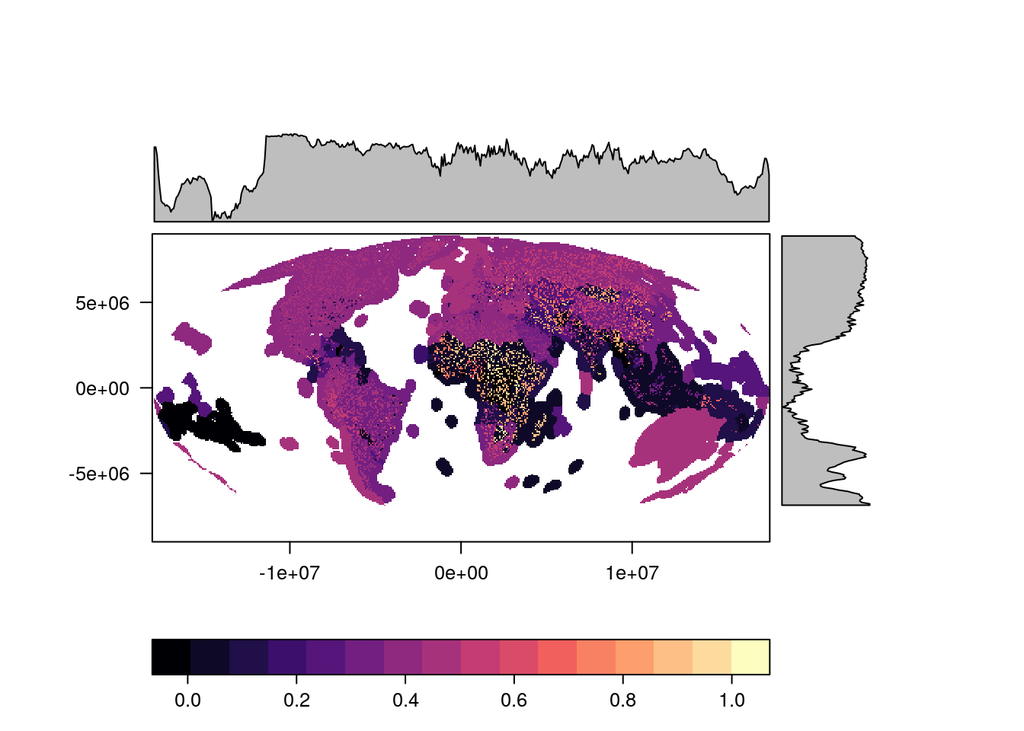

```r
rasterVis::levelplot(n_raster_rural_urban)
```

```r
file.remove(nitrogen_factors_raster_fn)
```

```
## [1] TRUE
```

```r
writeRaster(x = n_raster_rural_urban,
            filename = nitrogen_factors_raster_fn)
```